# Trabajo final. Geoinformática 2019-2020

##### Fernanda Gaytán Camarillo y Janet Milanez Figueroa

### Análisis espacial: Autocorrelación

#### En este Notebook haremos un análisis de la autocorrelación espacial de las emisiones de contaminantes en la Zona Metropolitana del Valle de México. Como vimos en la exploración de datos, los Compuestos Orgánicos Volátiles (COV) son muy importantes en la CDMX, nosotras somos residentes de esta ciudad, es por esto que primero haremos la autocorrelación espacial utilizando esa variable.

[figure not shown]

### Nuestra base de datos en este momento no tiene geometría, es un dataframe cualquiera, así que primero hay que agregarle la información espacial y crear un GeoDataFrame

```python
#lIBRERIAS QUE VAMOS A UTILIZAR
%matplotlib inline

import seaborn as sns
import pandas as pd
import shapefile as shp
import numpy as np
import matplotlib.pyplot as plt
```

```python
import geopandas as gpd
```

```python
import mapclassify as classify
```

```python
#Carga los datos csv
df = pd.read_csv("C:/Users/fersh/Google Drive (fgaytan@centrogeo.edu.mx)/Tercer Cuatrimestre/Fundamentos de Geoinformática/Trabajo_final/aespacial/emissions.csv")
#Carga de geometrías
mun =  gpd.read_file("C:/Users/fersh/Google Drive (fgaytan@centrogeo.edu.mx)/Tercer Cuatrimestre/Fundamentos de Geoinformática/Trabajo_final/aespacial/zmvm.shp")
```

```python
#Veamos que si tiene un campo con la geometría
mun.dtypes
```

```
CVE_ENT        object
CVE_MUN        object
CVEGEO         object
NOM_ENT        object
AREA          float64
PERIMETER     float64
NOM_MUN        object
COV_            int64
COV_ID          int64
geometry     geometry
dtype: object
```

```python
#Para ahorrarnos problemas hay que estandarizar los tipos de variables que nos interesa que estén iguales en ambas bases
convert_dict = {'CVE_ENT': int,
                'CVEGEO': int
               }

mun = mun.astype(convert_dict)
df = df.astype(convert_dict)
print(mun.dtypes)
```

```
CVE_ENT         int32
CVE_MUN        object
CVEGEO          int32
NOM_ENT        object
AREA          float64
PERIMETER     float64
NOM_MUN        object
COV_            int64
COV_ID          int64
geometry     geometry
dtype: object
```

```python
df.dtypes
```

```
CVEGEO       int32
DEL_MUN     object
PM10       float64
PM25       float64
NOX        float64
COV        float64
NOM_MUN     object
CVE_ENT      int32
CVE_MUN      int64
dtype: object
```

#### Crear GeoDataFrame

Nosotros solo necesitamos la clave geográfica(CVEGEO) y la geometría del shapefile "mun" para poder unirla a los datos de emisiones y no tener variables extras que nos estorben. Por ello, extraeremos en un objeto esas variables de interés y posteriormente realizaremos la unión.

```python
mun_shapes = mun[['geometry', 'CVEGEO']]
```

```python
emisiones  = mun_shapes.merge(df, on='CVEGEO', how='right')
gdf = gpd.GeoDataFrame(emisiones)
gdf.head()
```

|  | geometry | CVEGEO | DEL_MUN | PM10 | PM25 | NOX | COV | NOM_MUN | CVE_ENT | CVE_MUN |
| --- | --- | --- | --- | --- | --- | --- | --- | --- | --- | --- |
| 0 | POLYGON ((-98.84075 19.63558, -98.84076 19.635... | 15002 | Acolman | 68.653593 | 17.777834 | 47.334930 | 95.577450 | Acolman | 15 | 2 |
| 1 | POLYGON ((-99.18906 19.39559, -99.18871 19.394... | 9010 | Alvaro Obregon | 2.568828 | 1.713469 | 19.052067 | 520.790620 | Alvaro Obregon | 9 | 10 |
| 2 | POLYGON ((-98.63921 19.16356, -98.63817 19.160... | 15009 | Amecameca | 81.311355 | 20.421787 | 47.396392 | 21.686285 | Amecameca | 15 | 9 |
| 3 | POLYGON ((-99.11815 20.02930, -99.11815 20.028... | 15010 | Apaxco | 44.923059 | 11.103629 | 26.922286 | 35.463659 | Apaxco | 15 | 10 |
| 4 | POLYGON ((-98.97257 19.59649, -98.97245 19.596... | 15011 | Atenco | 33.553189 | 8.642810 | 22.000338 | 28.519336 | Atenco | 15 | 11 |

```python
# Fija el CRS manualmente.
gdf.crs = {'init': u'epsg:32614'}
gdf.info()
```

```
<class 'geopandas.geodataframe.GeoDataFrame'>
Int64Index: 76 entries, 0 to 75
Data columns (total 10 columns):
 #   Column    Non-Null Count  Dtype
---  ------    --------------  -----
 0   geometry  76 non-null     geometry
 1   CVEGEO    76 non-null     int32
 2   DEL_MUN   76 non-null     object
 3   PM10      76 non-null     float64
 4   PM25      76 non-null     float64
 5   NOX       76 non-null     float64
 6   COV       76 non-null     float64
 7   NOM_MUN   76 non-null     object
 8   CVE_ENT   76 non-null     int32
 9   CVE_MUN   76 non-null     int64
dtypes: float64(4), geometry(1), int32(2), int64(1), object(2)
memory usage: 5.9+ KB
```

### Ya tenemos nuestro GeoDataFrame y ya tiene proyección, eso quiere decir que ya podemos visualizar nuestros datos de emisiones de contaminantes en la Zona Metropolitana del Valle de México:

```python
var_int = ['PM10', 'PM25', 'COV', 'NOX']
```

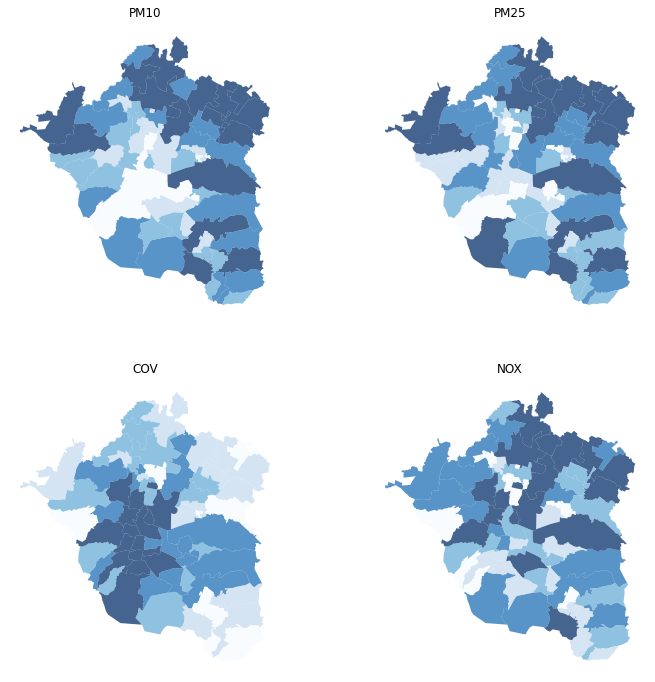

```python
# establecemos el número de filas y columnas que queremos para la cuadrícula de subplots
f, axs = plt.subplots(nrows=2, ncols=2, figsize=(12, 12))
# desempaquetamos la cuadrícula en una lista plana (matriz) para los ejes de cada subtrama que podemos recorrer
axs = axs.flatten()
# configuramos un bucle for para trazar un mapa en cada una de las subgráficas
for i, col in enumerate(var_int):
    # Dentro del ciclo extraemos el eje
    ax = axs[i]
    #  trazamos la coropleta y diseñamos el mapa
    gdf.plot(column=col, ax=ax, scheme='Quantiles', \
             linewidth=0, cmap='Blues', alpha=0.75)
    # Remueve "basura" del eje
    ax.set_axis_off()
    # Le pone el nombre de la variable a cada eje
    ax.set_title(col)
# Despliega la figura
plt.show()
```

### COV es la variable con la que vamos a seguir adelante con la explicación detallada de la visualización y el análisis de autocorrelación espacial

### Compuestos Orgánicos Volátiles, lo que nos dice el mapa:

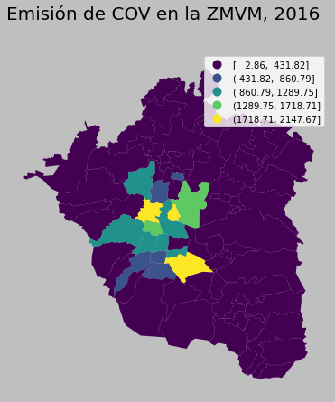

```python
# Mismas características que el mapa anterior con excepción de la clasificación
f, ax = plt.subplots(1, figsize=(7, 7))
gdf.plot(column='COV', scheme='equalinterval',
        legend=True, ax=ax)
ax.set_axis_off()
f.set_facecolor('0.75')
f.suptitle('Emisión de COV en la ZMVM, 2016', size=20)
plt.show()
```

```
array([[<matplotlib.axes._subplots.AxesSubplot object at 0x00000221A60BFBE0>]],
      dtype=object)
```

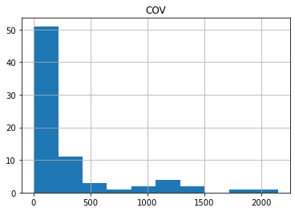

```python
#Estos valores del mapa están muy extremos, veamos el histograma
gdf.hist(column='COV')
```

Esto quiere decir que hay muchos municipios con valores muy chiquitos de COV, pero existen valores extremos que se alejan mucho de la media

### Vamos a obtener la matriz de pesos de nuestros datos, la cual nos servirá para todas las variables por igual

```python
##conda install pysal==1.14.4
##este es el código en la terminal
import contextily as ctx
import pysal as ps

np.random.seed(123)
```

```python
#Crea la matriz de pesos espaciales
%time w = ps.weights.Queen.from_dataframe(gdf)
```

```
Wall time: 762 ms
```

```python
# Estandariza los renglones de la matriz de pesos
#Significa que no va a ser binario, la suma de los elementos del renglón es igual a 1
w.transform = 'R'
```

Una vez que tenemos la matriz de pesos espaciales, calculamos la variable de retardo espacial para nuestra variable de ejemplo, que es la variable COV.

### **Retardo espacial**: es el producto de la matriz de pesos y la variable. Si la matriz de pesos está estandarizada por renglones, el resultado da el valor de las emisiones en la vecindad de cada observación

```python
#Creamos una nueva variable que contendrá este dato de retardo espacial caculado
#la función que calcula el retardo espacial, ps.lag_spatial, necesita la matriz de pesos, w
gdf['w_COV'] = ps.lag_spatial(w, gdf['COV'])
```

```python
gdf[['CVEGEO', 'COV', 'w_COV']]
```

|  | CVEGEO | COV | w_COV |
| --- | --- | --- | --- |
| 0 | 15002 | 95.577450 | 243.881357 |
| 1 | 9010 | 520.790620 | 511.746342 |
| 2 | 15009 | 21.686285 | 13.496410 |
| 3 | 15010 | 35.463659 | 29.789231 |
| 4 | 15011 | 28.519336 | 283.783249 |
| ... | ... | ... | ... |
| 71 | 15122 | 113.673148 | 628.086793 |
| 72 | 9017 | 387.788454 | 829.190474 |
| 73 | 15112 | 24.122761 | 215.108227 |
| 74 | 9013 | 312.093741 | 709.231473 |
| 75 | 15120 | 77.690105 | 93.982954 |

76 rows × 3 columns

```python
#Retardo espacial del resto de los contaminantes
#----PM10------
gdf['w_PM10'] = ps.lag_spatial(w, gdf['PM10'])
#----PM2.5------
gdf['w_PM25'] = ps.lag_spatial(w, gdf['PM25'])
#----NOX------
gdf['w_NOX'] = ps.lag_spatial(w, gdf['NOX'])
```

### **Variable estandarizada**. Para algunas aplicaciones hace más sentido el trabajar con una versión estandarizada de la variable, en lugar de la variable original. Esto es, extraer la media de los valores y dividir por la desviación estandar cada observación:

```python
#Diagrama de dispersión en términos de unidades estandarizadas
#Pasar los valores a datos entre 0 y 1
#Estandarización de la variable original. Para ello creamos una nueva columna que tendrá la variable estandarizada
gdf['COV_std'] = (gdf['COV'] - gdf['COV'].mean()) / gdf['COV'].std()

#Y obtenemos también la variable de retardo espacial estandarizada en otra columna nueva
gdf['w_COV_std'] = ps.lag_spatial(w, gdf['COV_std'])
```

```python
gdf[['CVEGEO', 'COV', 'w_COV','COV_std','w_COV_std']]
```

|  | CVEGEO | COV | w_COV | COV_std | w_COV_std |
| --- | --- | --- | --- | --- | --- |
| 0 | 15002 | 95.577450 | 243.881357 | -0.413105 | -0.089533 |
| 1 | 9010 | 520.790620 | 511.746342 | 0.514632 | 0.494899 |
| 2 | 15009 | 21.686285 | 13.496410 | -0.574322 | -0.592191 |
| 3 | 15010 | 35.463659 | 29.789231 | -0.544263 | -0.556643 |
| 4 | 15011 | 28.519336 | 283.783249 | -0.559414 | -0.002475 |
| ... | ... | ... | ... | ... | ... |
| 71 | 15122 | 113.673148 | 628.086793 | -0.373624 | 0.748732 |
| 72 | 9017 | 387.788454 | 829.190474 | 0.224445 | 1.187504 |
| 73 | 15112 | 24.122761 | 215.108227 | -0.569006 | -0.152311 |
| 74 | 9013 | 312.093741 | 709.231473 | 0.059293 | 0.925775 |
| 75 | 15120 | 77.690105 | 93.982954 | -0.452132 | -0.416584 |

76 rows × 5 columns

```python
#Variable estandarizada y la variable de retardo espacial estandarizada del resto de los contaminantes
#----PM10------
gdf['PM10_std'] = (gdf['PM10'] - gdf['PM10'].mean()) / gdf['PM10'].std()
gdf['w_PM10_std'] = ps.lag_spatial(w, gdf['PM10_std'])
#----PM2.5------
gdf['PM25_std'] = (gdf['PM25'] - gdf['PM25'].mean()) / gdf['PM25'].std()
gdf['w_PM25_std'] = ps.lag_spatial(w, gdf['PM25_std'])
#----NOX------
gdf['NOX_std'] = (gdf['NOX'] - gdf['NOX'].mean()) / gdf['NOX'].std()
gdf['w_NOX_std'] = ps.lag_spatial(w, gdf['NOX_std'])
```

### **Autocorrelación espacial**

Ahora si, con la variable estandarizada podemos crear el diagrama de dispersión de Moran.

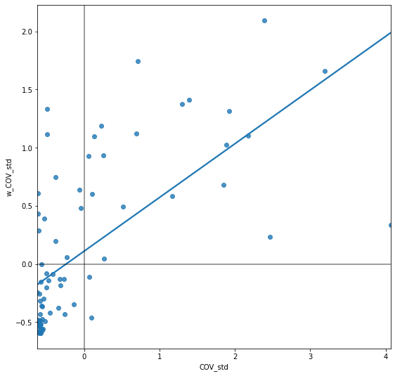

```python
# Ajustamos la figura y los ejes
f, ax = plt.subplots(1, figsize=(9, 9))
# Graficamos
sns.regplot(x='COV_std', y='w_COV_std', data=gdf, ci=None)
# Agergamos líneas horizontal y vertical
plt.axvline(0, c='k', alpha=0.5)
plt.axhline(0, c='k', alpha=0.5)
# Despliegue
plt.show()
```

###### **I de Moran**

A continuación calculamos la I de Moran

```python
mi = ps.Moran(gdf['COV'], w)
```

```python
#Desplegamos el valor de la I de Moran
mi.I
```

```
0.4621598655129938
```

```python
# Obtenemos la pseudo significancia del patrón observado
mi.p_sim
```

```
0.001
```

```python
#Indice de Moran del resto de los contaminantes
#----PM10------
mi_PM10 = ps.Moran(gdf['PM10'], w)
#----PM2.5------
mi_PM25 = ps.Moran(gdf['PM25'], w)
#----NOX------
mi_NOX = ps.Moran(gdf['NOX'], w)
```

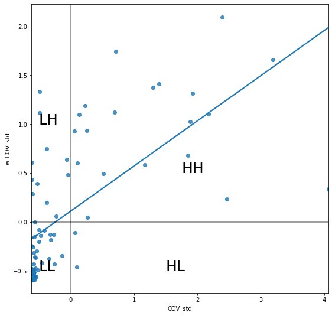

```python
# Ajustamos la figura y los ejes
f, ax = plt.subplots(1, figsize=(9, 9))
# Graficamos los valores
sns.regplot(x='COV_std', y='w_COV_std', data=gdf, ci=None)
# Agregamos líneas verticales, horizontales y etiquetas
plt.axvline(0, c='k', alpha=0.5)
plt.axhline(0, c='k', alpha=0.5)
plt.text(1.75, 0.5, "HH", fontsize=25)
plt.text(1.5, -0.5, "HL", fontsize=25)
plt.text(-0.5, 1, "LH", fontsize=25)
plt.text(-0.5, -0.5, "LL", fontsize=25)
# Desplegamos la gráfica
plt.show()
```

### **Autocorrelación espacial local**

Calculamos los indicadores locales de asociación espacial. Solo requerimos la variable de interés y la matriz de pesos espaciales. Podemos separar las observaciones en las que son significativas y las que no lo son.

```python
lisa = ps.Moran_Local(gdf['COV'], w)
```

```python
# Separa a las observaciones en significativas o no
gdf['sig_COV'] = lisa.p_sim < 0.05
# Almacenamos el cuadrante al que pertenecen las observaciones
gdf['quad_COV'] = lisa.q
```

```python
gdf['sig_COV']
```

```
0     False
1     False
2      True
3     False
4     False
      ...
71    False
72     True
73    False
74     True
75    False
Name: sig_COV, Length: 76, dtype: bool
```

```python
#Cuadrante al que pertenecen
gdf['quad_COV']
```

```
0     3
1     1
2     3
3     3
4     3
     ..
71    2
72    1
73    3
74    1
75    3
Name: quad_COV, Length: 76, dtype: int32
```

```python
#Indice de Moran Local, significancia y cuadrantes del resto de las variables
#----PM10------
lisa_PM10 = ps.Moran_Local(gdf['PM10'], w)
gdf['sig_PM10'] = lisa_PM10.p_sim < 0.05
gdf['quad_PM10'] = lisa_PM10.q
#----PM2.5------
lisa_PM25 = ps.Moran_Local(gdf['PM25'], w)
gdf['sig_PM25'] = lisa_PM25.p_sim < 0.05
gdf['quad_PM25'] = lisa_PM25.q
#----NOX------
lisa_NOX = ps.Moran_Local(gdf['NOX'], w)
gdf['sig_NOX'] = lisa_NOX.p_sim < 0.05
gdf['quad_NOX'] = lisa_NOX.q
```

### **Veamos el mapa de Autocorrelación espacial de COV**

Vamos a asignarle diferentes colores a los municipios dependiendo del cuadrante en el que se encuentran dada su autocorrelación local

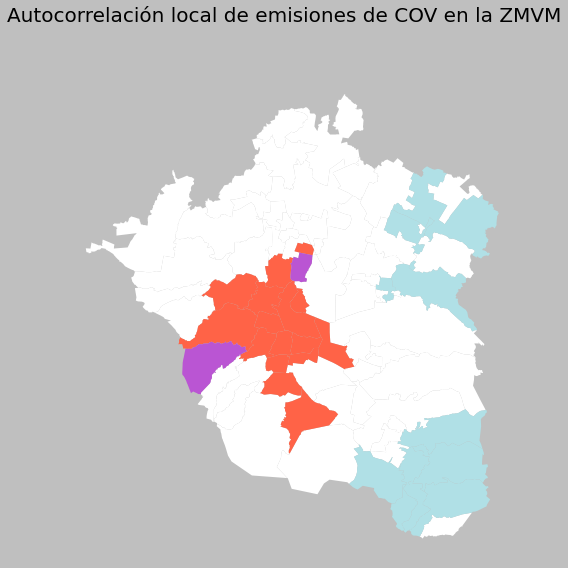

```python
# Ajusta la figura y los ejes
f, ax = plt.subplots(1, figsize=(9, 9))
# Grafica observaciones no significativas
ns = gdf.loc[gdf['sig_COV']==False, 'geometry']
ns.plot(ax=ax, color='white')
# Grafica clusters Alto-Alto
hh = gdf.loc[(gdf['quad_COV']==1) & (gdf['sig_COV']==True), 'geometry']
hh.plot(ax=ax, color='#FF6347')
# Grafica clusters Bajo-Bajo
ll = gdf.loc[(gdf['quad_COV']==3) & (gdf['sig_COV']==True), 'geometry']
ll.plot(ax=ax, color='#B0E0E6')
# Grafica anomalías espaciales Bajo-ALto
lh = gdf.loc[(gdf['quad_COV']==2) & (gdf['sig_COV']==True), 'geometry']
lh.plot(ax=ax, color='#BA55D3')
# Grafica anomalías espaciales Alto-Bajo
hl = gdf.loc[(gdf['quad_COV']==4) & (gdf['sig_COV']==True), 'geometry']
hl.plot(ax=ax, color='#FFC0CB')
# Estilo y despliegue
f.suptitle('Autocorrelación local de emisiones de COV en la ZMVM', size=20)
f.set_facecolor('0.75')
ax.set_axis_off()
plt.show()
```

### **Ya calculamos para todas nuestras variables (COV,PM10, PM25, NOX) los valores necesarios para poder realizar la gráfica de autocorrelación y para poder visualizarlas en el mapa. Estas variables se pueden observar ya en el GeoDataFrame:**

```python
#Retardo espacial
gdf[['CVEGEO', 'w_COV', 'w_PM10','w_PM25', 'w_NOX']].head()
```

|  | CVEGEO | w_COV | w_PM10 | w_PM25 | w_NOX |
| --- | --- | --- | --- | --- | --- |
| 0 | 15002 | 243.881357 | 38.211350 | 10.709614 | 43.770437 |
| 1 | 9010 | 511.746342 | 12.888526 | 4.776170 | 26.388067 |
| 2 | 15009 | 13.496410 | 41.447944 | 10.574757 | 24.408401 |
| 3 | 15010 | 29.789231 | 107.346452 | 27.221455 | 64.711860 |
| 4 | 15011 | 283.783249 | 34.535363 | 10.176715 | 46.415477 |

```python
#Variable estandarizada
gdf[['CVEGEO', 'COV_std','PM10_std', 'PM25_std','NOX_std']].head()
```

|  | CVEGEO | COV_std | PM10_std | PM25_std | NOX_std |
| --- | --- | --- | --- | --- | --- |
| 0 | 15002 | -0.413105 | 0.579482 | 0.526341 | 0.116564 |
| 1 | 9010 | 0.514632 | -0.820880 | -0.839724 | -0.582082 |
| 2 | 15009 | -0.574322 | 0.847705 | 0.751175 | 0.118083 |
| 3 | 15010 | -0.544263 | 0.076623 | -0.041213 | -0.387671 |
| 4 | 15011 | -0.559414 | -0.164309 | -0.250474 | -0.509253 |

```python
#Variable de retardo espacial estandarizada
gdf[['CVEGEO', 'w_COV_std','w_PM10_std', 'w_PM25_std','w_NOX_std']].head()
```

|  | CVEGEO | w_COV_std | w_PM10_std | w_PM25_std | w_NOX_std |
| --- | --- | --- | --- | --- | --- |
| 0 | 15002 | -0.089533 | -0.065601 | -0.074719 | 0.028514 |
| 1 | 9010 | 0.494899 | -0.602201 | -0.579281 | -0.400867 |
| 2 | 15009 | -0.592191 | 0.002984 | -0.086187 | -0.449769 |
| 3 | 15010 | -0.556643 | 1.399399 | 1.329398 | 0.545811 |
| 4 | 15011 | -0.002475 | -0.143496 | -0.120035 | 0.093852 |

```python
#Observaciones significativas
gdf[['CVEGEO', 'sig_COV','sig_PM10', 'sig_PM25','sig_NOX']].head()
```

|  | CVEGEO | sig_COV | sig_PM10 | sig_PM25 | sig_NOX |
| --- | --- | --- | --- | --- | --- |
| 0 | 15002 | False | False | False | False |
| 1 | 9010 | False | True | True | False |
| 2 | 15009 | True | False | False | False |
| 3 | 15010 | False | True | False | False |
| 4 | 15011 | False | False | False | False |

```python
#Cuadrantes de las observaciones
gdf[['CVEGEO', 'quad_COV','quad_PM10', 'quad_PM25','quad_NOX']].head()
```

|  | CVEGEO | quad_COV | quad_PM10 | quad_PM25 | quad_NOX |
| --- | --- | --- | --- | --- | --- |
| 0 | 15002 | 3 | 4 | 4 | 1 |
| 1 | 9010 | 1 | 3 | 3 | 3 |
| 2 | 15009 | 3 | 1 | 4 | 4 |
| 3 | 15010 | 3 | 1 | 2 | 2 |
| 4 | 15011 | 3 | 3 | 3 | 2 |

### **También calculamos el índice de Moran y la significancia de cada variable.Estos valores se guardaron en objetos que podemos acomodar en un dataframe para poder visualizarlo fácilmente:**

```python
vals = {'Contaminante': ['COV', 'PM10', 'PM25', 'NOX'], 'Indice Moran': [mi.I, mi_PM10.I, mi_PM25.I, mi_PM25.I], 'Significancia': [mi.p_sim, mi_PM10.p_sim, mi_PM25.p_sim, mi_PM25.p_sim]}
ind_mor = pd.DataFrame(data=vals)
ind_mor
```

[output not shown]

### **Gráficos y mapas**

A continuación veremos los gráficos de autocorrelación espacial del resto de los contaminantes y sus mapas de autocorrelación espacial local, con la distinción entre cuadrantes. Empezando por:

#### PM10-Material particulado de 10 micrómetros:

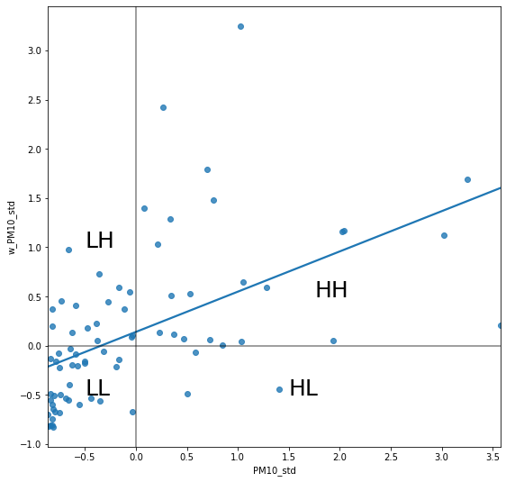

```python
f, ax = plt.subplots(1, figsize=(9, 9))
sns.regplot(x='PM10_std', y='w_PM10_std', data=gdf, ci=None)
plt.axvline(0, c='k', alpha=0.5)
plt.axhline(0, c='k', alpha=0.5)
plt.text(1.75, 0.5, "HH", fontsize=25)
plt.text(1.5, -0.5, "HL", fontsize=25)
plt.text(-0.5, 1, "LH", fontsize=25)
plt.text(-0.5, -0.5, "LL", fontsize=25)
plt.show()
```

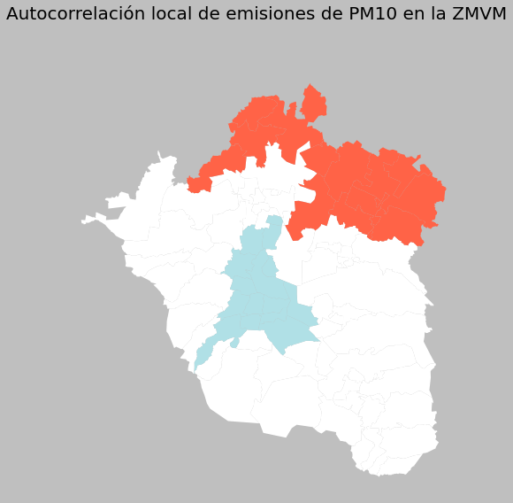

```python
f, ax = plt.subplots(1, figsize=(9, 9))
ns = gdf.loc[gdf['sig_PM10']==False, 'geometry']
ns.plot(ax=ax, color='white')
hh = gdf.loc[(gdf['quad_PM10']==1) & (gdf['sig_PM10']==True), 'geometry']
hh.plot(ax=ax, color='#FF6347')
ll = gdf.loc[(gdf['quad_PM10']==3) & (gdf['sig_PM10']==True), 'geometry']
ll.plot(ax=ax, color='#B0E0E6')
lh = gdf.loc[(gdf['quad_PM10']==2) & (gdf['sig_PM10']==True), 'geometry']
lh.plot(ax=ax, color='#BA55D3')
hl = gdf.loc[(gdf['quad_PM10']==4) & (gdf['sig_PM10']==True), 'geometry']
hl.plot(ax=ax, color='#FFC0CB')
# Estilo y despliegue
f.suptitle('Autocorrelación local de emisiones de PM10 en la ZMVM', size=20)
f.set_facecolor('0.75')
ax.set_axis_off()
plt.show()
```

#### PM25-Material particulado de 2.5 micrómetros:

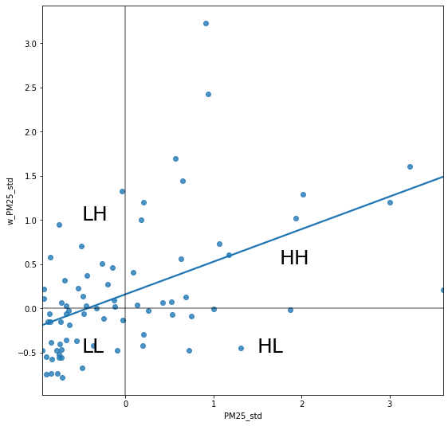

```python
f, ax = plt.subplots(1, figsize=(9, 9))
sns.regplot(x='PM25_std', y='w_PM25_std', data=gdf, ci=None)
plt.axvline(0, c='k', alpha=0.5)
plt.axhline(0, c='k', alpha=0.5)
plt.text(1.75, 0.5, "HH", fontsize=25)
plt.text(1.5, -0.5, "HL", fontsize=25)
plt.text(-0.5, 1, "LH", fontsize=25)
plt.text(-0.5, -0.5, "LL", fontsize=25)
plt.show()
```

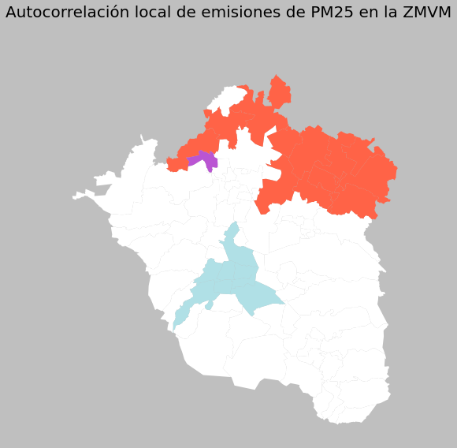

```python
f, ax = plt.subplots(1, figsize=(9, 9))
ns = gdf.loc[gdf['sig_PM25']==False, 'geometry']
ns.plot(ax=ax, color='white')
hh = gdf.loc[(gdf['quad_PM25']==1) & (gdf['sig_PM25']==True), 'geometry']
hh.plot(ax=ax, color='#FF6347')
ll = gdf.loc[(gdf['quad_PM25']==3) & (gdf['sig_PM25']==True), 'geometry']
ll.plot(ax=ax, color='#B0E0E6')
lh = gdf.loc[(gdf['quad_PM25']==2) & (gdf['sig_PM25']==True), 'geometry']
lh.plot(ax=ax, color='#BA55D3')
hl = gdf.loc[(gdf['quad_PM25']==4) & (gdf['sig_PM25']==True), 'geometry']
hl.plot(ax=ax, color='#FFC0CB')
# Estilo y despliegue
f.suptitle('Autocorrelación local de emisiones de PM25 en la ZMVM', size=20)
f.set_facecolor('0.75')
ax.set_axis_off()
plt.show()
```

#### NOX-Óxido de Nitrógeno:

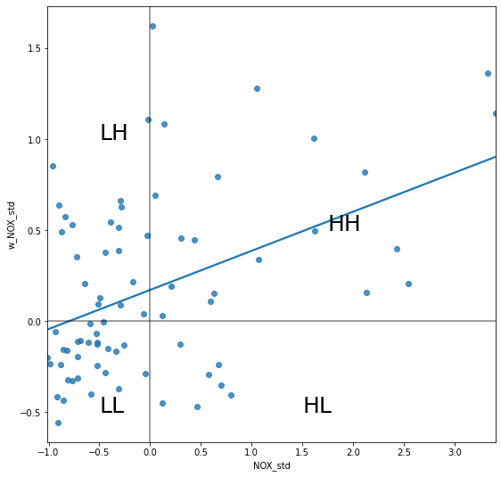

```python
f, ax = plt.subplots(1, figsize=(9, 9))
sns.regplot(x='NOX_std', y='w_NOX_std', data=gdf, ci=None)
plt.axvline(0, c='k', alpha=0.5)
plt.axhline(0, c='k', alpha=0.5)
plt.text(1.75, 0.5, "HH", fontsize=25)
plt.text(1.5, -0.5, "HL", fontsize=25)
plt.text(-0.5, 1, "LH", fontsize=25)
plt.text(-0.5, -0.5, "LL", fontsize=25)
plt.show()
```

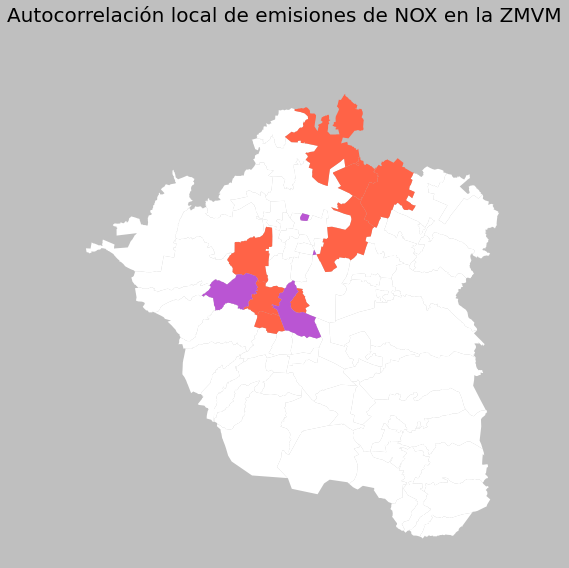

```python
f, ax = plt.subplots(1, figsize=(9, 9))
ns = gdf.loc[gdf['sig_NOX']==False, 'geometry']
ns.plot(ax=ax, color='white')
hh = gdf.loc[(gdf['quad_NOX']==1) & (gdf['sig_NOX']==True), 'geometry']
hh.plot(ax=ax, color='#FF6347')
ll = gdf.loc[(gdf['quad_NOX']==3) & (gdf['sig_NOX']==True), 'geometry']
ll.plot(ax=ax, color='#B0E0E6')
lh = gdf.loc[(gdf['quad_NOX']==2) & (gdf['sig_NOX']==True), 'geometry']
lh.plot(ax=ax, color='#BA55D3')
hl = gdf.loc[(gdf['quad_NOX']==4) & (gdf['sig_NOX']==True), 'geometry']
hl.plot(ax=ax, color='#FFC0CB')
# Estilo y despliegue
f.suptitle('Autocorrelación local de emisiones de NOX en la ZMVM', size=20)
f.set_facecolor('0.75')
ax.set_axis_off()
plt.show()
```

```python
#Guardamos nuestro shp para hacer un geojson
gdf.to_file("emisiones.shp")
```

```python
!jupyter nbconvert  aespacial.ipynb --to html
```

```
[NbConvertApp] Converting notebook aespacial.ipynb to html
[NbConvertApp] Writing 1093313 bytes to aespacial.html
```